# MATH1115 Computer Practical Exam (SAMPLE EXAM No.2 + ANSWERS)

Semester 1 2019

*Note: below is a sample exam.*

It is based on the `flights` dataset, which is provided by the `nycflights13` package. It contains information about all flights originated from three New York airports in 2013. Each row of the data represents a flight originated from one of three New York airports.

Below is given some suggested code in the code blocks. In your exam, the code blocks will be mostly blank, with some occasional hints provided.

## MY SID IS: XXXXX

# 1 Initial Data Analysis

Load packages and data

```r
library(tidyverse)
library(nycflights13)

data("flights", package = "nycflights13")
```

## 1.1 Question 1. Subsetting data 1

The `flights` data is the data that we will be using for this exam. So it is important for us to know what these columns represent:

1. `dep_delay`, the departure delay for each flight, in minutes
2. `arr_delay`, the arrival delay for each flight, in minutes
3. `carrier`, the airline carrier of each flight. Due to Question 1, we only have `AA` and `VX` in this column.
4. `origin`, the origin of each flight. Since only New York flights were considered, this column only contains value `JFK`, `LGA`, `EWR`.
5. `dest`, the destination of each flight. It only has a three-letters airport abbreviation for each flight.
6. There are other columns in this data, but we will throw them away in Question 2
- Explain what does this code do on the `flights` data?

**Hint**: the code `AA` stands for “American Airline” and `VX` stands for “Virgin American Airline”.

```r
selected_flights = flights %>%
  dplyr::filter(carrier %in% c("AA", "VX"))
```

## 1.2 Question 2: Subsetting data 2

Subset `selected_flights` to only have the columns `dep_delay`, `arr_delay`, `carrier`, `origin` and `dest`. Save this new data as an object called `small_flights`.

This is the data that we will be using for the rest of this exam. So it is important for us to know what these columns represent:

1. `dep_delay`, the departure delay for each flight, in minutes
2. `arr_delay`, the arrival delay for each flight, in minutes
3. `carrier`, the airline carrier of each flight. Due to Question 1, we only have `AA` and `VX` in this column.
4. `origin`, the origin of each flight. Since only New York flights were considered, this column only contains value `JFK`, `LGA`, `EWR`.
5. `dest`, the destination of each flight. It only has a three-letters airport abbreviation for each flight.

```r
# Add your code below

small_flights = selected_flights %>%
  dplyr::select(dep_delay, arr_delay, carrier, origin, dest)
```

## 1.3 Question 3: Initial Data Analysis

Conduct an initial data analysis on `small_flights` to determine the structure of your data. Write a concise summary.

```r
# Add your code below

help(small_flights)
```

```
## No documentation for 'small_flights' in specified packages and libraries:
## you could try '??small_flights'
```

```r
glimpse(small_flights)
```

```
## Observations: 37,891
## Variables: 5
## $ dep_delay <dbl> 2, -2, -1, -4, 13, -2, -1, 0, -4, -3, -2, -1, -3, -6, …
## $ arr_delay <dbl> 33, 8, 31, -12, 5, -3, 14, 48, 4, -10, 2, -7, -12, 31,…
## $ carrier   <chr> "AA", "AA", "AA", "AA", "AA", "AA", "AA", "AA", "AA", …
## $ origin    <chr> "JFK", "LGA", "LGA", "EWR", "LGA", "JFK", "LGA", "LGA"…
## $ dest      <chr> "MIA", "ORD", "DFW", "MIA", "MIA", "SJU", "ORD", "DFW"…
```

The data set contains 37,891 entries, with 5 variables, representing various information about each flight in and out of the three New York airports.

## 1.4 Question 4: Three airports in New York City

There are three airports in the city of New York. These are coded as the `origin` variable.

- `JKF` (John F. Kennedy International Airport)
- `LGA` (LaGuardia Airport)
- `EWR` (Newark Liberty International Airport)

In R, calculate the number of flights from each of these airports by **each** of these `carrier`. (i.e. construct a 3-by-2 `table` or a summary `data.frame`). Which one of the three airports does Virgin America Airline NOT operating from?

```r
table(small_flights$origin, small_flights$carrier)
```

```
##
##          AA    VX
##   EWR  3487  1566
##   JFK 13783  3596
##   LGA 15459     0
```

```r
selected_flights %>%
  group_by(carrier, origin) %>%
  dplyr::summarise(n())
```

```
## # A tibble: 5 x 3
## # Groups:   carrier [2]
##   carrier origin `n()`
##   <chr>   <chr>  <int>
## 1 AA      EWR     3487
## 2 AA      JFK    13783
## 3 AA      LGA    15459
## 4 VX      EWR     1566
## 5 VX      JFK     3596
```

- VX does not operate from `LGA` airport.

## 1.5 Question 5: Data filtering

What are the values of the 5 most heaviest arrival delays in this data?

Which airline carrier operated all these 5 flights?

(Hint: positive value of `arr_delay` indicates delays in minutes.)

```r
# Add your code

small_flights %>%
  arrange(desc(arr_delay))
```

```
## # A tibble: 37,891 x 5
##    dep_delay arr_delay carrier origin dest
##        <dbl>     <dbl> <chr>   <chr>  <chr>
##  1      1014      1007 AA      JFK    SFO
##  2       896       878 AA      EWR    MIA
##  3       853       852 AA      JFK    LAS
##  4       845       846 AA      EWR    MIA
##  5       803       802 AA      LGA    STL
##  6       761       783 AA      JFK    IAH
##  7       797       783 AA      JFK    LAS
##  8       629       676 VX      JFK    SFO
##  9       660       648 AA      LGA    MIA
## 10       580       645 AA      EWR    MIA
## # … with 37,881 more rows
```

```r
## Or


small_flights %>%
  arrange(-arr_delay)
```

```
## # A tibble: 37,891 x 5
##    dep_delay arr_delay carrier origin dest
##        <dbl>     <dbl> <chr>   <chr>  <chr>
##  1      1014      1007 AA      JFK    SFO
##  2       896       878 AA      EWR    MIA
##  3       853       852 AA      JFK    LAS
##  4       845       846 AA      EWR    MIA
##  5       803       802 AA      LGA    STL
##  6       761       783 AA      JFK    IAH
##  7       797       783 AA      JFK    LAS
##  8       629       676 VX      JFK    SFO
##  9       660       648 AA      LGA    MIA
## 10       580       645 AA      EWR    MIA
## # … with 37,881 more rows
```

## 1.6 Question 6: Arrival delays 1

- Provide one appropriate visualisation of the variable `arr_delay` using `ggplot2`.
- Describe the pattern of arrival delay.

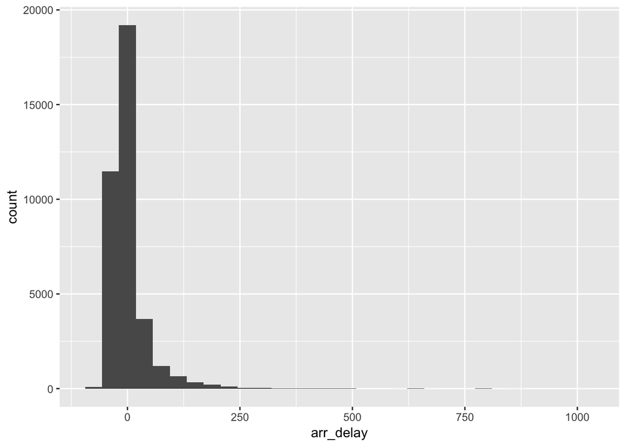

```r
# Add your code

small_flights %>%
  ggplot(aes(x = arr_delay)) +
  geom_histogram()
```

This data is highly skewed to the right.

## 1.7 Question 7: Arrival delay 2

- Would a normal model be appropriate to model arrival delay (`arr_delay`)?
- Are there more late arrivals (positive value of `arr_delay`) or early arrival (negative value of `arr_delay`)?

Note: You must use at least one appropriate graphical (`ggplot2` is not necessary) or numerical tool.

```r
summary(small_flights$arr_delay)
```

```
##      Min.   1st Qu.    Median      Mean   3rd Qu.      Max.      NA's
##  -86.0000  -22.0000   -9.0000    0.5576    8.0000 1007.0000       828
```

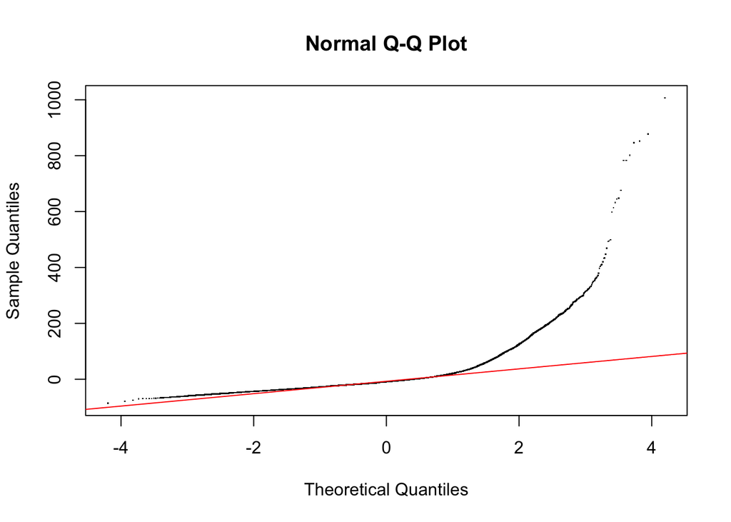

```r
qqnorm(small_flights$arr_delay, pch = ".")
qqline(small_flights$arr_delay, col = "red")
```

```r
table(sign(small_flights$arr_delay))
```

```
##
##    -1     0     1
## 24045   566 12452
```

- The Normal model appears to fit poorly based on the qq-plot.
- There are more values of negatives in this data looking at the histogram in the question above. This is confirmed by the `sign()` function outpu.

# 2 Simple Linear Regression

## 2.1 Question 8: Linear regression between `arr_delay` and `dep_delay` 1.

- Plot `arr_delay` (y) against `dep_delay` (x) in a scatter plot (`ggplot2` is not necessary).
- Provide two general comments for this scatter plot.

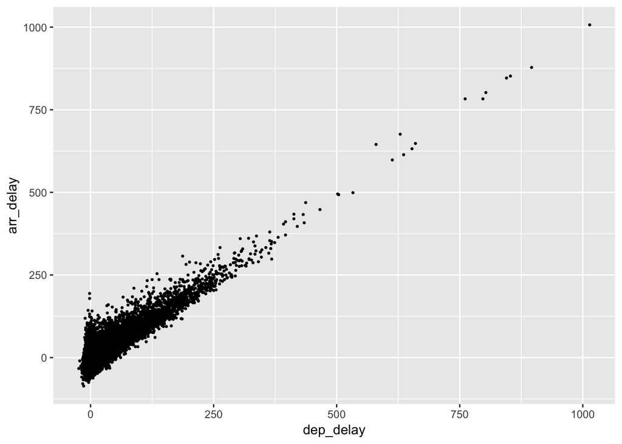

```r
small_flights %>%
  ggplot(aes(x = dep_delay, y = arr_delay)) +
  geom_point(size = 0.5)
```

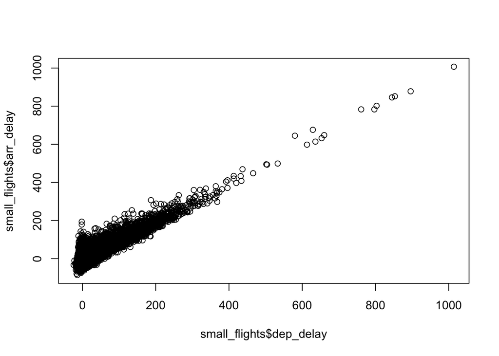

```r
## Or

plot(small_flights$dep_delay, small_flights$arr_delay)
```

## 2.2 Question 9: Linear regression between `arr_delay` and `dep_delay` 2.

- Compute a linear regression model for `arr_delay` (y) against `dep_delay` (x). State clearly what are the intercept term and slope term for this linear regression model.
- Show the linear regression model on your scatter plot as a coloured line (`ggplot2` is not necessary).

```r
M = lm(dep_delay ~ arr_delay, data = small_flights)
M
```

```
##
## Call:
## lm(formula = dep_delay ~ arr_delay, data = small_flights)
##
## Coefficients:
## (Intercept)    arr_delay
##      8.7081       0.7875
```

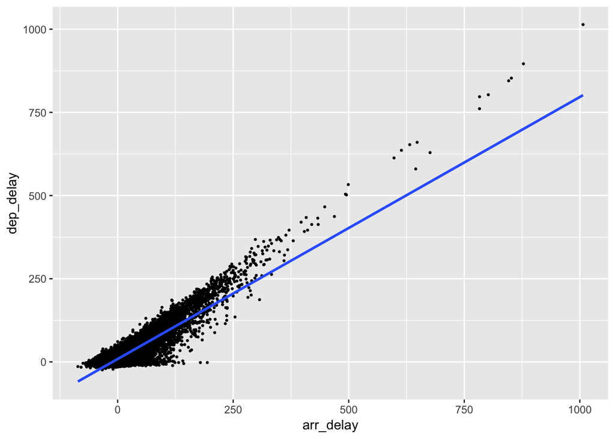

```r
small_flights %>%
  ggplot(aes(x = arr_delay, y = dep_delay)) +
  geom_point(size = 0.5) +
  geom_smooth(method = "lm")
```

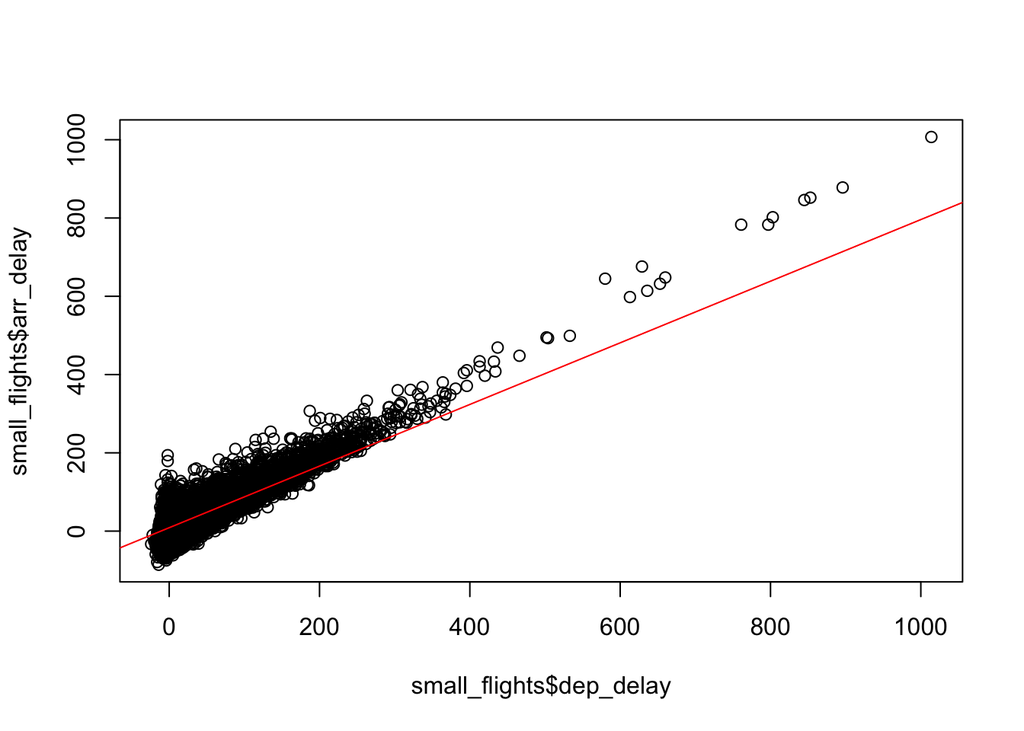

```r
## Or

plot(small_flights$dep_delay, small_flights$arr_delay)
abline(M, col = "red")
```

## 2.3 Question 10: Linear regression between `arr_delay` and `dep_delay` 3.

- Suppose there are two flights, A and B, departing from an unknown New York airports. During departure, flight A was delayed by 5 minutes and flight B was delayed by 30 minutes. Based on the model we have computed in Question 9, compute the predicted difference in the arrival delay times for these two flights (2 decimal places).

The prediction equation for A is $y = a + b*5$ and for B is $y = a + b*30$. So the difference is $25*b$.

```r
M
```

```
##
## Call:
## lm(formula = dep_delay ~ arr_delay, data = small_flights)
##
## Coefficients:
## (Intercept)    arr_delay
##      8.7081       0.7875
```

```r
0.7875 * (30-5)
```

```
## [1] 19.6875
```

## 2.4 Question 11: Chi-square test 1

It is postulated that the carriers (`AA` and `VX`) are independent to the origin airports. Test this hypothesis.

```r
# Put your code here

table(small_flights$carrier, small_flights$origin)
```

```
##
##        EWR   JFK   LGA
##   AA  3487 13783 15459
##   VX  1566  3596     0
```

```r
chisq.test(
  table(small_flights$carrier, small_flights$origin)
)
```

```
##
##  Pearson's Chi-squared test
##
## data:  table(small_flights$carrier, small_flights$origin)
## X-squared = 4471.4, df = 2, p-value < 2.2e-16
```

## 2.5 Question 11: Chi-square test 2

```r
# Put your code here

## From the previous question
chisq.test(c(3487, 13783, 15459), p = c(10, 40, 45)/sum(c(10, 40, 45)))
```

```
##
##  Chi-squared test for given probabilities
##
## data:  c(3487, 13783, 15459)
## X-squared = 0.63466, df = 2, p-value = 0.7281
```

# 3 Binomial modelling

## 3.1 Question 12: Binomial modelling

Suppose we restrict our attention to the JFK airport and only the AA and VX flights. Also, suppose the probablility of selecting a flight that is AA is 0.9 and the probability of selecting a flight that is VX is 0.1.

- Construct a box model that represents this situation and draw a sample of size 100 from this box. You may assume AA is coded as “0” and VX is coded as “1”.
- Calculate the expected value and standard error of the total number of VX flights based on this sample of 100.

```r
library(multicon)
size = 100
x = sample(c(0,1), prob = c(0.9, 0.1), size = size, replace = TRUE)
```

```r
size * mean(x)
```

```
## [1] 8
```

```r
sqrt(size) * popsd(x)
```

```
## [1] 2.712932
```

## 3.2 Question 13: Binomial model

What is the probability that out of a random sample of 100 flights, that less than 15 flights are from the carrier VX? (Using a binomial model or an appropriate normal approximation)

```r
pbinom(15, size = size, prob = 0.1, lower.tail = T)
```

```
## [1] 0.9601095
```

```r
box2 = c(rep(0, 9), 1)
pnorm(15, mean = size*mean(box2), sd = sqrt(size)*popsd(box2))
```

```
## [1] 0.9522096
```